# SCOOPS survey data analysis

## Response counts

Responses from outside of study range (before start, on weekend, or too late in the day): 138

Responses from not eating at Cardinal Sage: 64

Number of responses from each week/condition:

| week | condition | n |
| --- | --- | --- |
| 1 | control | 151 |
| 2 | intervention | 96 |
| 3 | control | 68 |
| 4 | intervention | 49 |

| condition | n |
| --- | --- |
| control | 219 |
| intervention | 145 |

## Demographic breakdown

Diet information

| category | value | n | prop |
| --- | --- | --- | --- |
| diet | Meat | 227 | 0.6236 |
| diet | Flexitarian | 81 | 0.2225 |
| diet | Vegetarian | 26 | 0.0714 |
| diet | Vegan | 18 | 0.0495 |
| diet | Pescatarian | 12 | 0.0330 |
| meat_freq | 8-14 | 141 | 0.3874 |
| meat_freq | 1-7 | 121 | 0.3324 |
| meat_freq | 0 | 58 | 0.1593 |
| meat_freq | 15-21 | 41 | 0.1126 |
| meat_freq | 22+ | 3 | 0.0082 |

[output cut: 6 more lines]

Demographic information

| category | value | n | prop |
| --- | --- | --- | --- |
| stanford_status | Sophomore | 119 | 0.3269 |
| stanford_status | Freshman | 114 | 0.3132 |
| stanford_status | Junior | 66 | 0.1813 |
| stanford_status | Senior | 35 | 0.0962 |
| stanford_status | Graduate student | 22 | 0.0604 |
| stanford_status | Other | 8 | 0.0220 |
| gender | Female | 205 | 0.5632 |
| gender | Male | 149 | 0.4093 |
| gender | Prefer not to answer | 5 | 0.0137 |
| gender | Non-binary | 5 | 0.0137 |

[output cut: 14 more lines]

## Plot responses

Plot values by week:

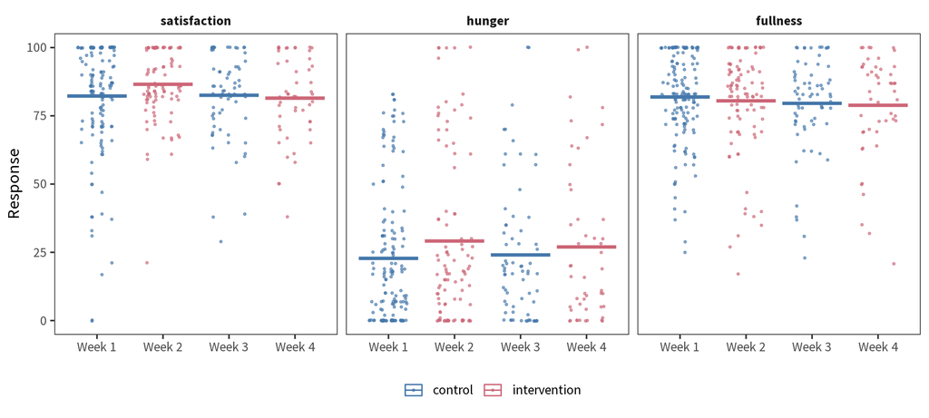

Plot values by condition:

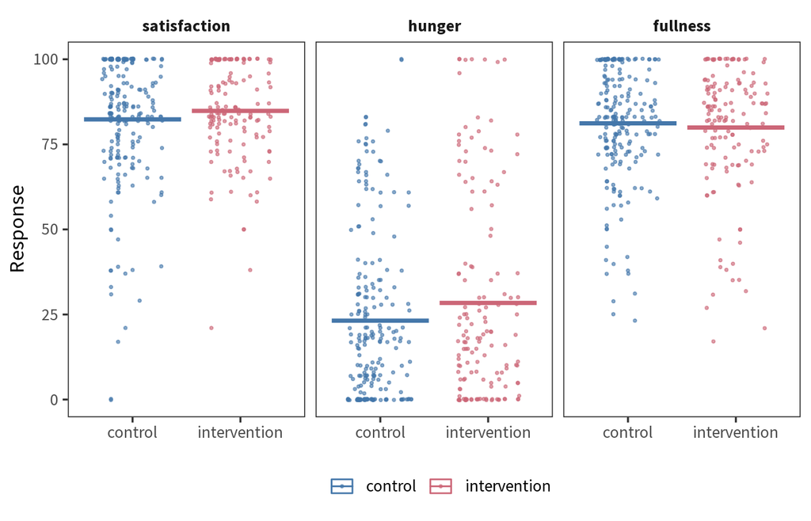

## Models

### Meat inclusion independence check

Check if intervention is affecting whether meat was eaten:

```
##
## Call:
## lm(formula = meat_inclusion ~ condition, data = survey_filtered)
##
## Residuals:
##    Min     1Q Median     3Q    Max
## -0.765 -0.699  0.234  0.301  0.301
##
## Coefficients:
##                       Estimate Std. Error t value Pr(>|t|)
## (Intercept)             0.6986     0.0302    23.2   <2e-16 ***
## conditionintervention   0.0669     0.0478     1.4     0.16
## ---
## Signif. codes:  0 '***' 0.001 '**' 0.01 '*' 0.05 '.' 0.1 ' ' 1
##
## Residual standard error: 0.45 on 362 degrees of freedom
## Multiple R-squared:  0.00538,    Adjusted R-squared:  0.00263
## F-statistic: 1.96 on 1 and 362 DF,  p-value: 0.163
```

| condition | .fitted | .lower | .upper | .se.fit |
| --- | --- | --- | --- | --- |
| control | 0.70 | 0.64 | 0.76 | 0.030 |
| intervention | 0.77 | 0.69 | 0.84 | 0.037 |

No effect of condition on meat inclusion.

### By condition

Differences by condition (condition is treatment coded):

**satisfaction**:

```
##
## Call:
## lm(formula = rating ~ condition, data = d)
##
## Residuals:
##    Min     1Q Median     3Q    Max
## -82.34  -7.83   1.66  15.17  17.66
##
## Coefficients:
##                       Estimate Std. Error t value Pr(>|t|)
## (Intercept)              82.34       1.16   71.12   <2e-16 ***
## conditionintervention     2.50       1.83    1.36     0.17
## ---
## Signif. codes:  0 '***' 0.001 '**' 0.01 '*' 0.05 '.' 0.1 ' ' 1
##
## Residual standard error: 17 on 362 degrees of freedom
## Multiple R-squared:  0.00509,    Adjusted R-squared:  0.00234
## F-statistic: 1.85 on 1 and 362 DF,  p-value: 0.174
```

**hunger**:

```
##
## Call:
## lm(formula = rating ~ condition, data = d)
##
## Residuals:
##    Min     1Q Median     3Q    Max
## -28.40 -23.18  -8.18  10.02  76.82
##
## Coefficients:
##                       Estimate Std. Error t value Pr(>|t|)
## (Intercept)              23.18       1.82   12.75   <2e-16 ***
## conditionintervention     5.22       2.88    1.81    0.071 .
## ---
## Signif. codes:  0 '***' 0.001 '**' 0.01 '*' 0.05 '.' 0.1 ' ' 1
##
## Residual standard error: 27 on 362 degrees of freedom
## Multiple R-squared:  0.009,  Adjusted R-squared:  0.00626
## F-statistic: 3.29 on 1 and 362 DF,  p-value: 0.0706
```

**fullness**:

```
##
## Call:
## lm(formula = rating ~ condition, data = d)
##
## Residuals:
##    Min     1Q Median     3Q    Max
## -62.94  -7.18   2.06  12.82  20.06
##
## Coefficients:
##                       Estimate Std. Error t value Pr(>|t|)
## (Intercept)              81.18       1.17   69.54   <2e-16 ***
## conditionintervention    -1.24       1.85   -0.67      0.5
## ---
## Signif. codes:  0 '***' 0.001 '**' 0.01 '*' 0.05 '.' 0.1 ' ' 1
##
## Residual standard error: 17 on 362 degrees of freedom
## Multiple R-squared:  0.00125,    Adjusted R-squared:  -0.00151
## F-statistic: 0.453 on 1 and 362 DF,  p-value: 0.501
```

**coefficients**:

| measure | term | estimate | std.error | statistic | p.value | conf.low | conf.high |
| --- | --- | --- | --- | --- | --- | --- | --- |
| satisfaction | (Intercept) | 82.3 | 1.2 | 71.12 | 0.00 | 80.06 | 84.6 |
| satisfaction | conditionintervention | 2.5 | 1.8 | 1.36 | 0.17 | -1.11 | 6.1 |
| hunger | (Intercept) | 23.2 | 1.8 | 12.75 | 0.00 | 19.60 | 26.8 |
| hunger | conditionintervention | 5.2 | 2.9 | 1.81 | 0.07 | -0.44 | 10.9 |
| fullness | (Intercept) | 81.2 | 1.2 | 69.54 | 0.00 | 78.89 | 83.5 |
| fullness | conditionintervention | -1.2 | 1.8 | -0.67 | 0.50 | -4.88 | 2.4 |

**fits**:

| measure | condition | .fitted | .lower | .upper | .se.fit |
| --- | --- | --- | --- | --- | --- |
| satisfaction | control | 82 | 80 | 85 | 1.2 |
| satisfaction | intervention | 85 | 82 | 88 | 1.4 |
| hunger | control | 23 | 20 | 27 | 1.8 |
| hunger | intervention | 28 | 24 | 33 | 2.2 |
| fullness | control | 81 | 79 | 83 | 1.2 |
| fullness | intervention | 80 | 77 | 83 | 1.4 |

No effect of condition on any of satisfaction, hunger, and fullness.

Plot responses by condition with CIs from above models:

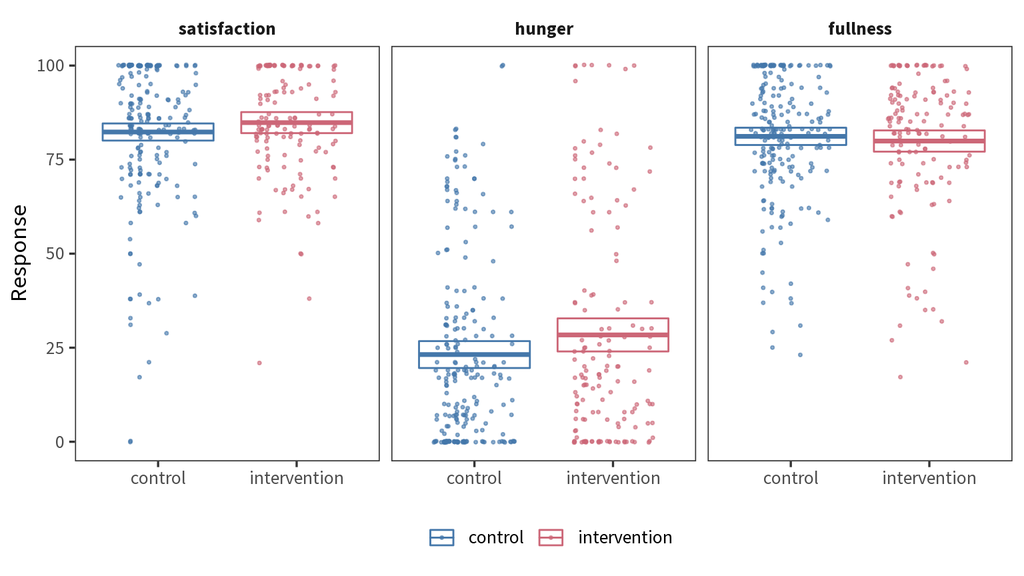

### By condition and meat type

Differences by condition and meat type (both are effects coded):

**satisfaction**:

```
##
## Call:
## lm(formula = rating ~ condition * meat_target, data = d)
##
## Residuals:
##    Min     1Q Median     3Q    Max
## -78.92  -7.12   1.71  12.62  21.08
##
## Coefficients:
##                         Estimate Std. Error t value Pr(>|t|)
## (Intercept)               83.819      1.011   82.89   <2e-16 ***
## condition1                -1.496      1.011   -1.48     0.14
## meat_target1               0.968      1.290    0.75     0.45
## meat_target2              -2.119      1.596   -1.33     0.19
## condition1:meat_target1    2.813      1.290    2.18     0.03 *
## condition1:meat_target2   -1.280      1.596   -0.80     0.42
## ---
## Signif. codes:  0 '***' 0.001 '**' 0.01 '*' 0.05 '.' 0.1 ' ' 1
##
## Residual standard error: 17 on 358 degrees of freedom
## Multiple R-squared:  0.0265, Adjusted R-squared:  0.0129
## F-statistic: 1.95 on 5 and 358 DF,  p-value: 0.0856
```

**hunger**:

```
##
## Call:
## lm(formula = rating ~ condition * meat_target, data = d)
##
## Residuals:
##    Min     1Q Median     3Q    Max
## -34.38 -19.86  -8.63   9.87  80.31
##
## Coefficients:
##                         Estimate Std. Error t value Pr(>|t|)
## (Intercept)                26.01       1.59   16.33   <2e-16 ***
## condition1                 -3.24       1.59   -2.03    0.043 *
## meat_target1               -1.88       2.03   -0.93    0.355
## meat_target2                1.80       2.51    0.72    0.475
## condition1:meat_target1    -1.21       2.03   -0.59    0.553
## condition1:meat_target2    -3.33       2.51   -1.32    0.186
## ---
## Signif. codes:  0 '***' 0.001 '**' 0.01 '*' 0.05 '.' 0.1 ' ' 1
##
## Residual standard error: 27 on 358 degrees of freedom
## Multiple R-squared:  0.0236, Adjusted R-squared:  0.00996
## F-statistic: 1.73 on 5 and 358 DF,  p-value: 0.127
```

**fullness**:

```
##
## Call:
## lm(formula = rating ~ condition * meat_target, data = d)
##
## Residuals:
##    Min     1Q Median     3Q    Max
## -63.46  -6.45   3.51  12.54  21.56
##
## Coefficients:
##                         Estimate Std. Error t value Pr(>|t|)
## (Intercept)               80.697      1.025   78.69   <2e-16 ***
## condition1                 0.745      1.025    0.73     0.47
## meat_target1               0.934      1.308    0.71     0.48
## meat_target2               0.312      1.619    0.19     0.85
## condition1:meat_target1    1.109      1.308    0.85     0.40
## condition1:meat_target2    0.645      1.619    0.40     0.69
## ---
## Signif. codes:  0 '***' 0.001 '**' 0.01 '*' 0.05 '.' 0.1 ' ' 1
##
## Residual standard error: 17 on 358 degrees of freedom
## Multiple R-squared:  0.0116, Adjusted R-squared:  -0.00222
## F-statistic: 0.839 on 5 and 358 DF,  p-value: 0.523
```

**coefficients**:

| measure | term | estimate | std.error | statistic | p.value | conf.low | conf.high |
| --- | --- | --- | --- | --- | --- | --- | --- |
| satisfaction | (Intercept) | 83.82 | 1.0 | 82.89 | 0.00 | 81.83 | 85.81 |
| satisfaction | condition1 | -1.50 | 1.0 | -1.48 | 0.14 | -3.49 | 0.49 |
| satisfaction | meat_target1 | 0.97 | 1.3 | 0.75 | 0.45 | -1.57 | 3.50 |
| satisfaction | meat_target2 | -2.12 | 1.6 | -1.33 | 0.19 | -5.26 | 1.02 |
| satisfaction | condition1:meat_target1 | 2.81 | 1.3 | 2.18 | 0.03 | 0.28 | 5.35 |
| satisfaction | condition1:meat_target2 | -1.28 | 1.6 | -0.80 | 0.42 | -4.42 | 1.86 |
| hunger | (Intercept) | 26.01 | 1.6 | 16.33 | 0.00 | 22.88 | 29.15 |
| hunger | condition1 | -3.24 | 1.6 | -2.03 | 0.04 | -6.37 | -0.10 |
| hunger | meat_target1 | -1.88 | 2.0 | -0.93 | 0.36 | -5.88 | 2.12 |
| hunger | meat_target2 | 1.80 | 2.5 | 0.72 | 0.47 | -3.15 | 6.74 |

[output cut: 8 more lines]

**fits**:

| measure | condition | meat_target | .fitted | .lower | .upper | .se.fit |
| --- | --- | --- | --- | --- | --- | --- |
| satisfaction | control | chicken | 86 | 82 | 90 | 2.1 |
| satisfaction | intervention | chicken | 83 | 80 | 87 | 1.8 |
| satisfaction | control | beef | 79 | 75 | 83 | 2.1 |
| satisfaction | intervention | beef | 84 | 77 | 92 | 3.7 |
| satisfaction | control | pork | 82 | 78 | 86 | 1.8 |
| satisfaction | intervention | pork | 88 | 83 | 93 | 2.7 |
| hunger | control | chicken | 20 | 13 | 26 | 3.3 |
| hunger | intervention | chicken | 29 | 23 | 34 | 2.9 |
| hunger | control | beef | 21 | 15 | 28 | 3.3 |
| hunger | intervention | beef | 34 | 23 | 46 | 5.9 |

[output cut: 8 more lines]

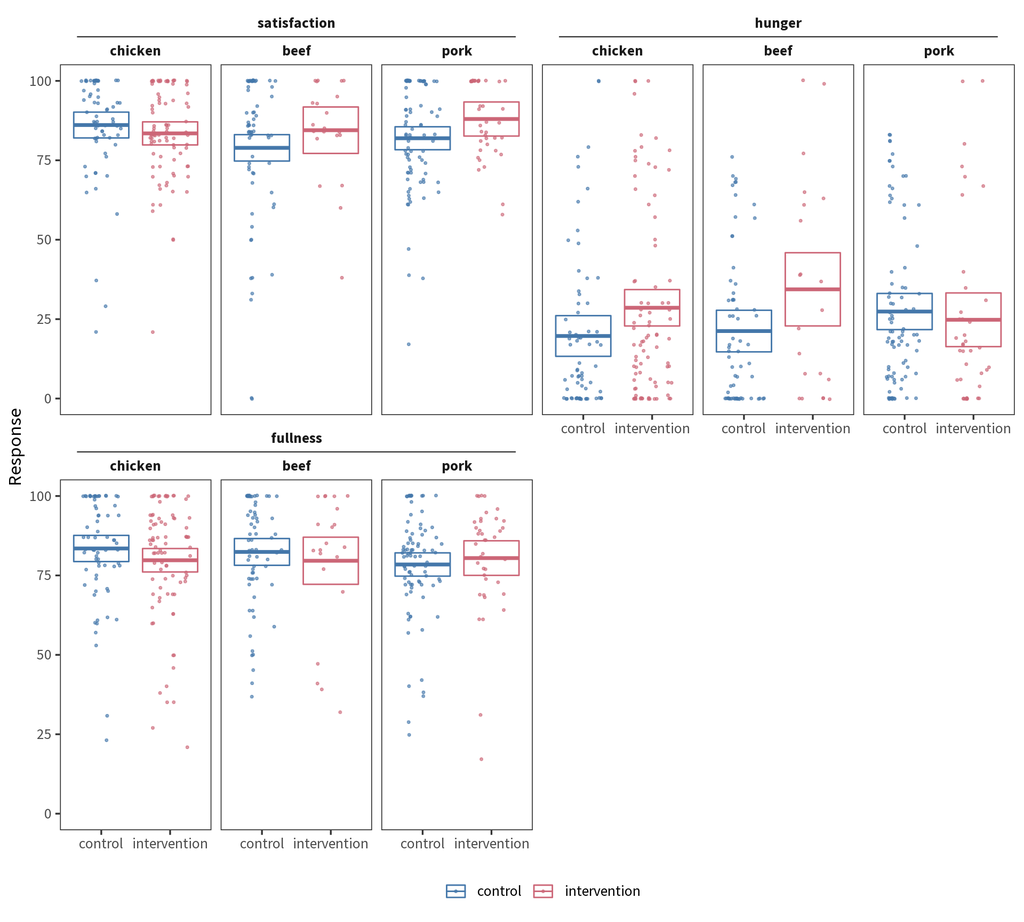

### By condition and meat inclusion

Differences by condition, split by whether meat was included:

**coefficients**:

| measure | meat_inclusion | term | estimate | std.error | statistic | p.value | conf.low | conf.high |
| --- | --- | --- | --- | --- | --- | --- | --- | --- |
| satisfaction | TRUE | (Intercept) | 84.488 | 0.98 | 86.163 | 0.00 | 82.6 | 86.42 |
| satisfaction | TRUE | condition1 | -1.521 | 0.98 | -1.551 | 0.12 | -3.5 | 0.41 |
| hunger | TRUE | (Intercept) | 26.423 | 1.72 | 15.384 | 0.00 | 23.0 | 29.80 |
| hunger | TRUE | condition1 | -4.037 | 1.72 | -2.350 | 0.02 | -7.4 | -0.65 |
| fullness | TRUE | (Intercept) | 81.390 | 1.07 | 75.977 | 0.00 | 79.3 | 83.50 |
| fullness | TRUE | condition1 | 0.858 | 1.07 | 0.801 | 0.42 | -1.3 | 2.97 |
| satisfaction | FALSE | (Intercept) | 80.939 | 2.15 | 37.681 | 0.00 | 76.7 | 85.20 |
| satisfaction | FALSE | condition1 | -0.061 | 2.15 | -0.028 | 0.98 | -4.3 | 4.20 |
| hunger | FALSE | (Intercept) | 23.346 | 2.63 | 8.884 | 0.00 | 18.1 | 28.56 |
| hunger | FALSE | condition1 | 1.669 | 2.63 | 0.635 | 0.53 | -3.5 | 6.88 |

[output cut: 2 more lines]

**fits**:

| measure | meat_inclusion | condition | .fitted | .lower | .upper | .se.fit |
| --- | --- | --- | --- | --- | --- | --- |
| satisfaction | TRUE | control | 83 | 80 | 85 | 1.3 |
| satisfaction | TRUE | intervention | 86 | 83 | 89 | 1.5 |
| hunger | TRUE | control | 22 | 18 | 27 | 2.2 |
| hunger | TRUE | intervention | 30 | 25 | 36 | 2.6 |
| fullness | TRUE | control | 82 | 80 | 85 | 1.4 |
| fullness | TRUE | intervention | 81 | 77 | 84 | 1.6 |
| satisfaction | FALSE | control | 81 | 76 | 86 | 2.5 |
| satisfaction | FALSE | intervention | 81 | 74 | 88 | 3.5 |
| hunger | FALSE | control | 25 | 19 | 31 | 3.1 |
| hunger | FALSE | intervention | 22 | 13 | 30 | 4.3 |

[output cut: 2 more lines]

No effects for satisfaction or fullness for both groups.

Might be an effect for hunger when including meat?

**hunger measure when meat was included**:

```
##
## Call:
## lm(formula = rating ~ condition, data = d)
##
## Residuals:
##    Min     1Q Median     3Q    Max
## -30.46 -22.39  -9.89   9.86  77.61
##
## Coefficients:
##             Estimate Std. Error t value Pr(>|t|)
## (Intercept)    26.42       1.72   15.38   <2e-16 ***
## condition1     -4.04       1.72   -2.35    0.019 *
## ---
## Signif. codes:  0 '***' 0.001 '**' 0.01 '*' 0.05 '.' 0.1 ' ' 1
##
## Residual standard error: 28 on 262 degrees of freedom
## Multiple R-squared:  0.0206, Adjusted R-squared:  0.0169
## F-statistic: 5.52 on 1 and 262 DF,  p-value: 0.0195
```

Respondents who ate meat responded 8.07 scale points higher in intervention that in control.

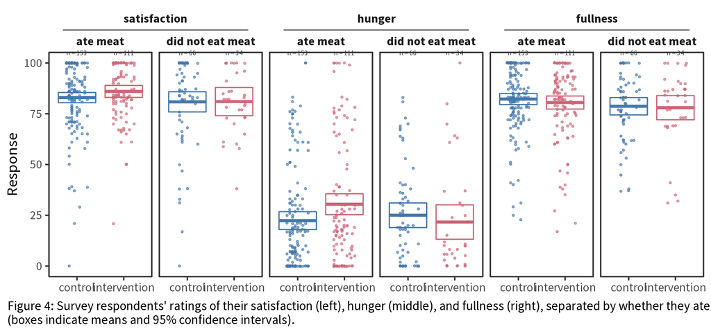

## Exploratory stuff

**demographic covariates**

| measure | demo | demo_value | n |
| --- | --- | --- | --- |
| satisfaction | gender | Male | 149 |
| satisfaction | gender | Female | 205 |
| satisfaction | gender | Other | 10 |
| satisfaction | diet | Meat | 227 |
| satisfaction | diet | Flexitarian | 81 |
| satisfaction | diet | Pescatarian/Vegetarian/Vegan | 56 |
| satisfaction | fish_freq | 0 | 58 |
| satisfaction | fish_freq | 1-7 | 121 |
| satisfaction | fish_freq | 8-14 | 141 |
| satisfaction | fish_freq | 15+ | 44 |

[output cut: 4 more lines]

[figure not shown]

**temporal trends**

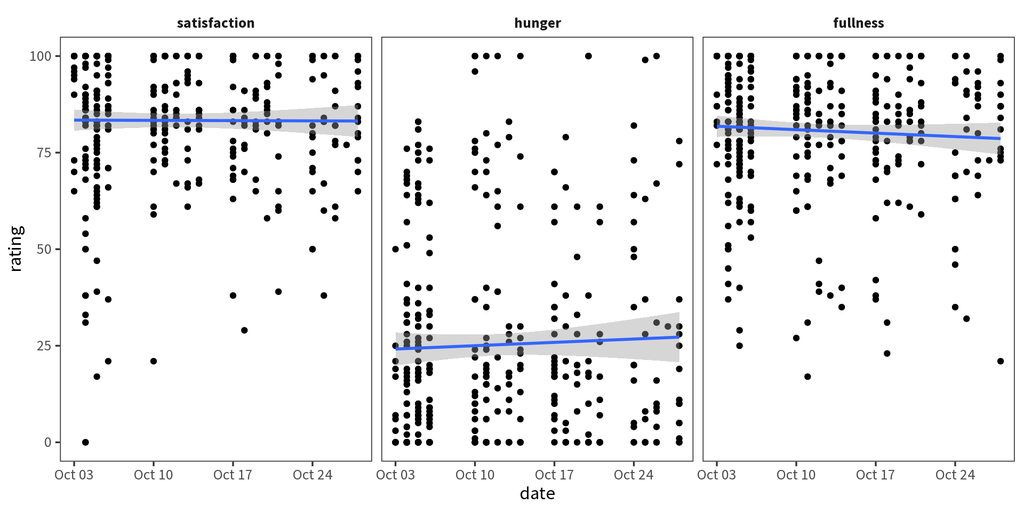

**day effects**

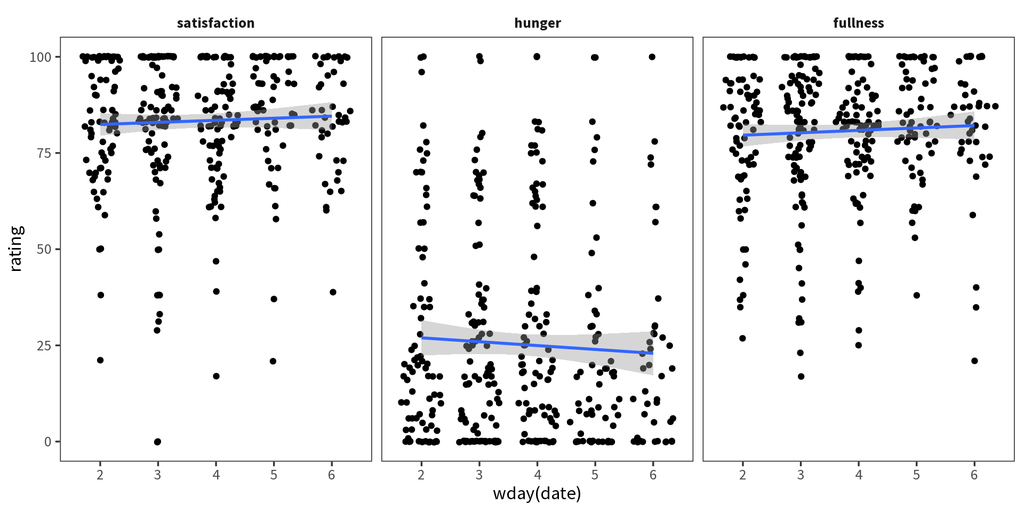